# Characterizing a built up filter

Erik Ø. Sørensen

2023-12-23

I made an attempt at getting my fancy audio interface (MOTU M4) to work with REW, but only ended up frustrated. Instead I grabbed my Analog Discovery 2, which can run in network analyzer mode using the “Waveforms” software. Unfortunately, the the analog discovery only has a 14 bit ADC and I haven’t got an easy to use amplifier within reach, so testing the MC output of the filter won’t be possible. I also expect a substantial amount of noise in the lower frequency, where there should be more than 60 dB of attenuation.

The setup is: BNC cable connecting output 1 from the Analog Discovery 2 generator 1 to the input of the filter, and similarly a BNC cable from the filter output back to the oscope input 1 on the Analog Discovery.

I have used the LT-spice software to calculate the expected true curve (under assumption of a low impedance signal generator (100 Ohm) and a high impedance receiver at the output of the filter).

First, let’s have a look at how the measurements compares to the calcuated numbers from LT-spice:

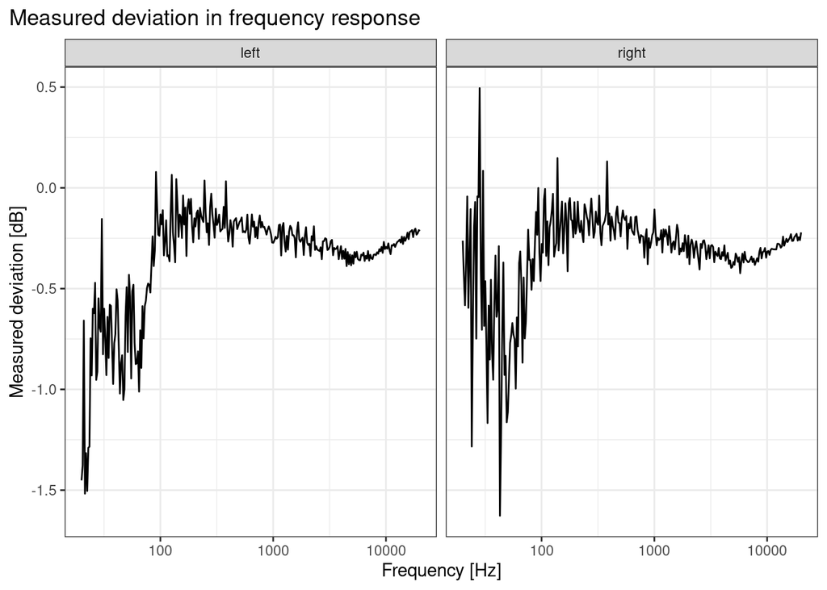

We see that there is a lot of noise below 100Hz, which is not strange taking the measurement equipment into account (and also some quantization error). Above 100Hz, most of the measurements, in both channels, are about 0.25dB attenuated compared to the LT-spice numbers. This variation from the predicted numbers in the levels isn’t really a problem.

As can be seen from the graph above, the channel balance is good. For reference, this is the deviation from perfect channel balance by frequency:

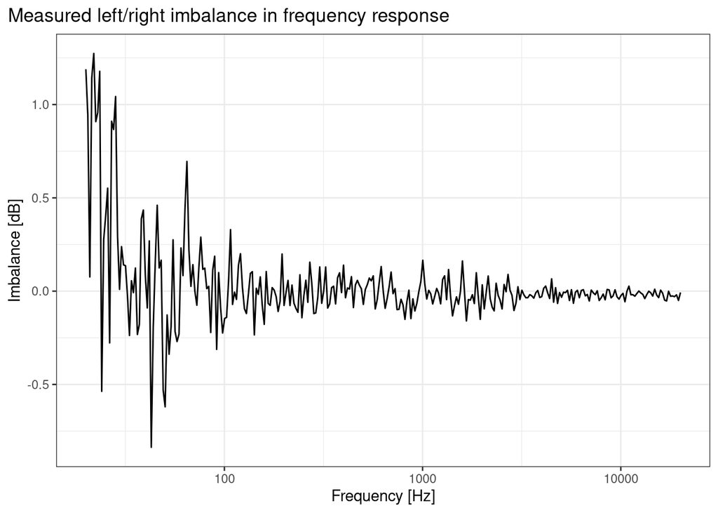